# Atlas Visual Sulawesi

### 5.0.19 Sinjai

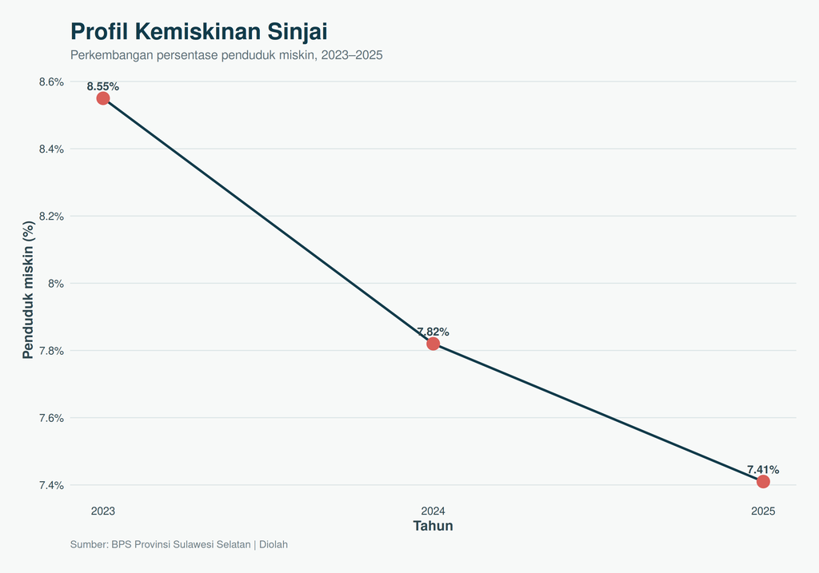

### 5.0.20 Soppeng

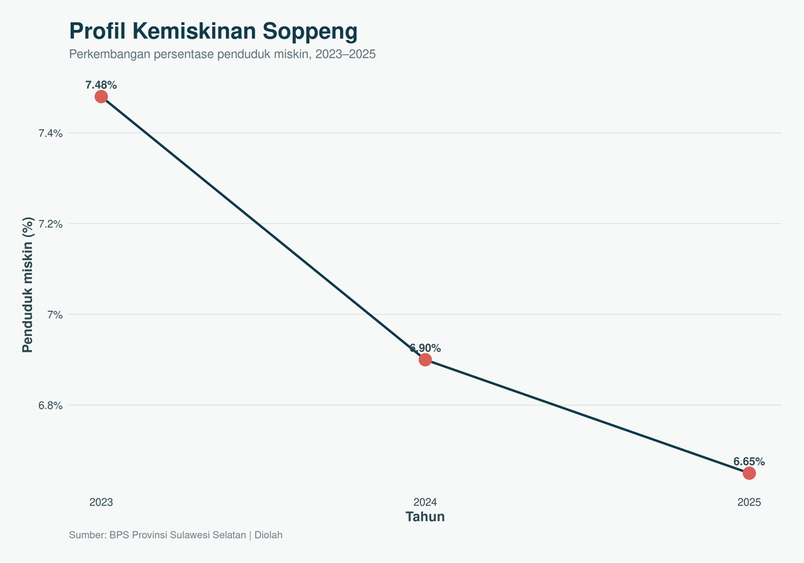

### 5.0.21 Takalar

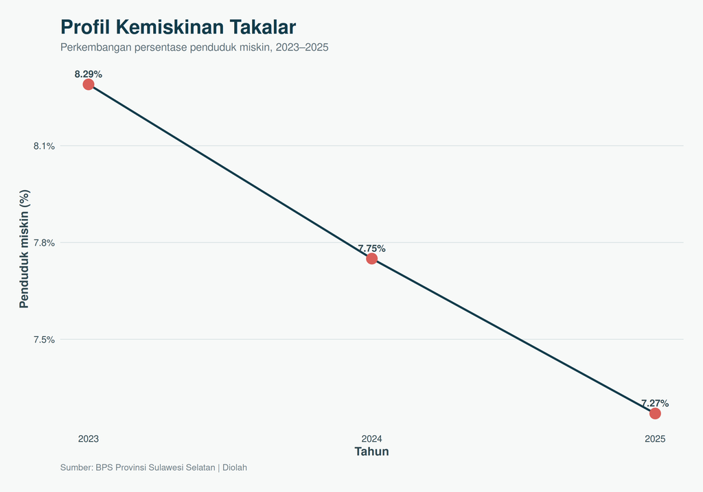

### 5.0.22 Tana Toraja

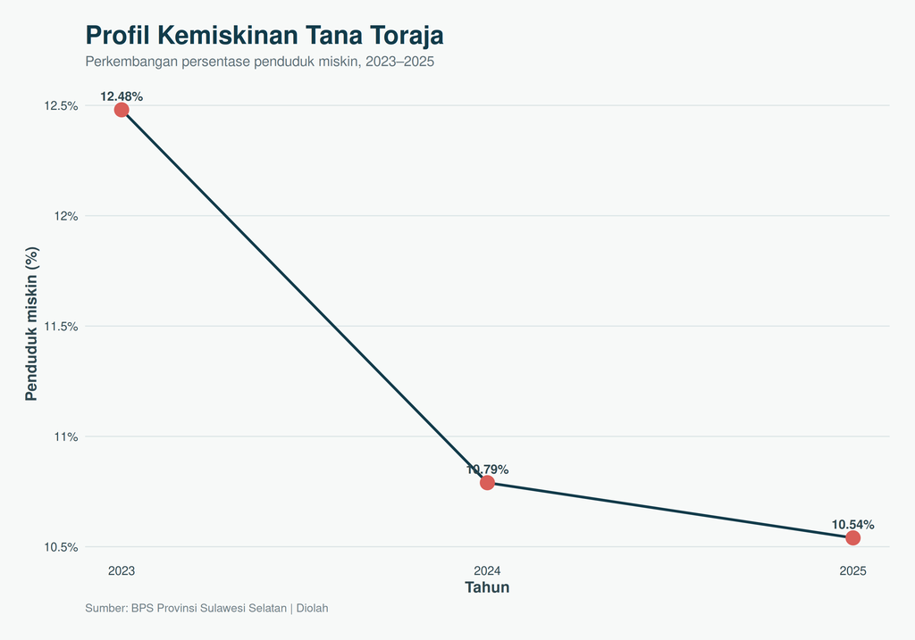

### 5.0.23 Toraja Utara

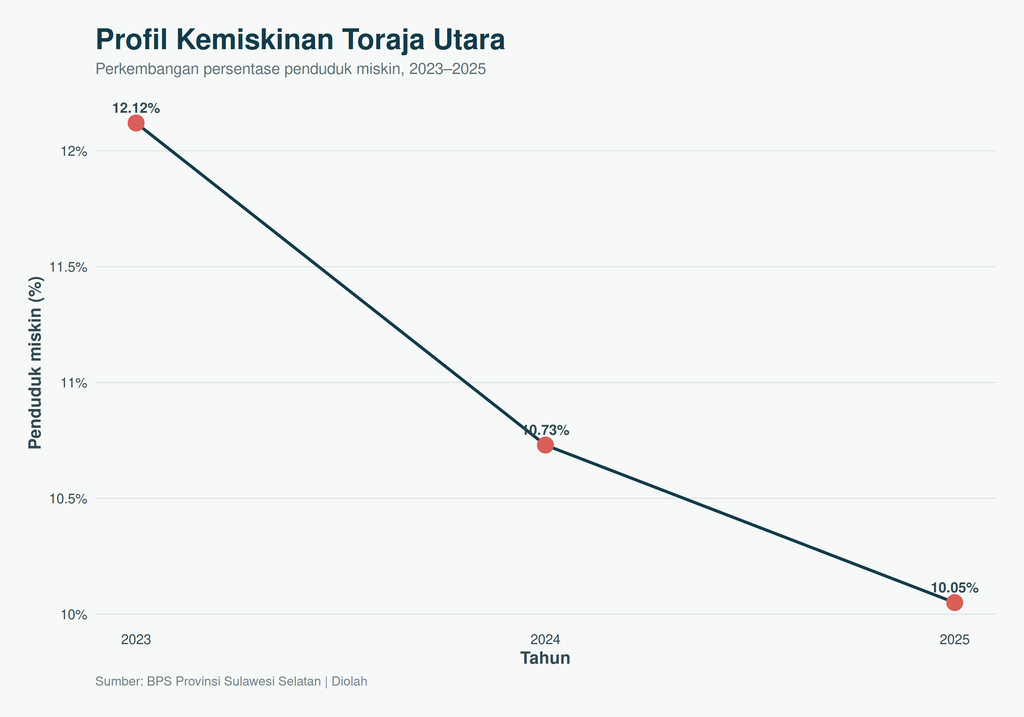

### 5.0.24 Wajo

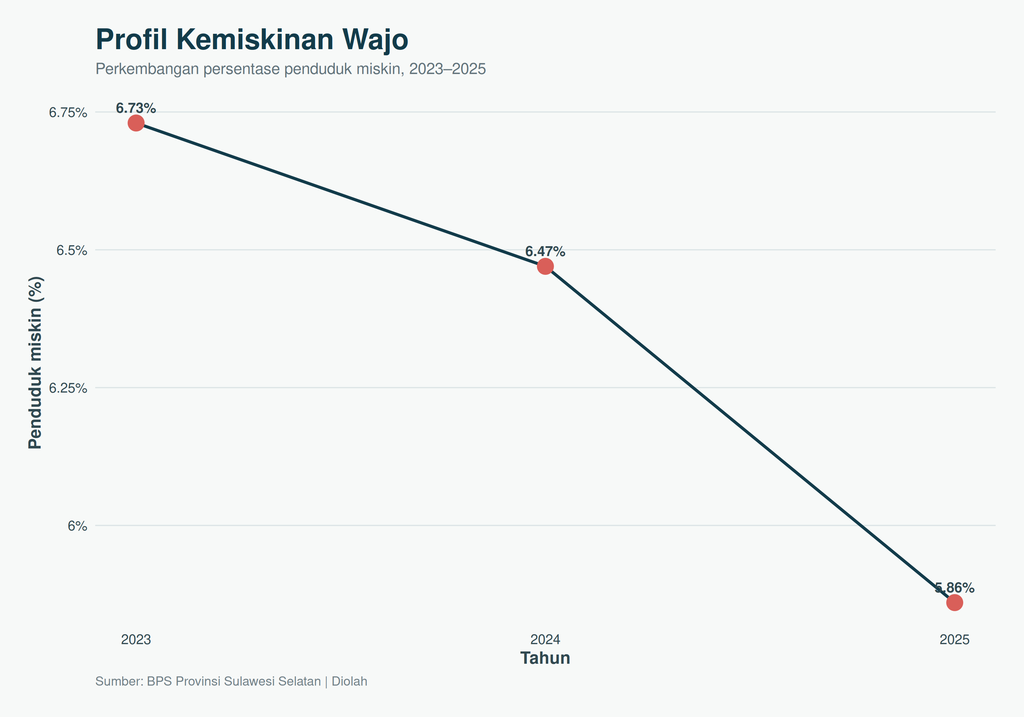

Bagian ini menyajikan profil visual 24 kabupaten/kota di Sulawesi Selatan. Setiap profil merangkum informasi mengenai tingkat kemiskinan selama periode 2023–2025, sehingga pembaca dapat melihat gambaran kondisi masing-masing wilayah.

# 6 Ketidakpastian: interval bootstrap

Grafik ini menampilkan estimasi rata-rata kemiskinan per wilayah beserta interval kepercayaan bootstrap 95%.

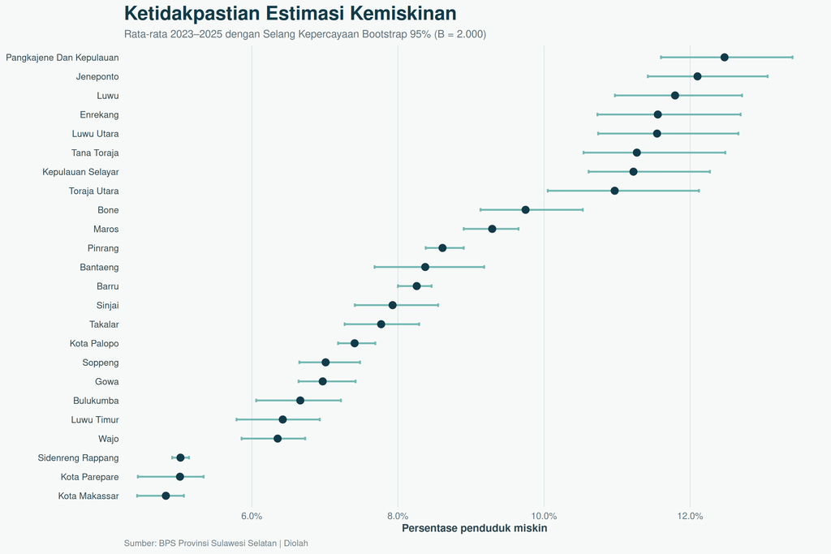

Estimasi dan interval kepercayaan bootstrap 95% untuk kemiskinan

Data tahunan yang digunakan mencakup tiga tahun (2023–2025), sehingga jumlah pengamatan per wilayah sangat terbatas. Interval bootstrap perlu ditafsirkan dengan hati-hati dan tidak dianggap sebagai ukuran ketidakpastian yang sangat presisi.

# 7 Inferensi visual: lineup

Lineup terdiri atas 20 panel, yaitu satu panel data asli dan 19 panel hasil permutasi. Pengamat diminta memilih panel yang terlihat paling berbeda dari panel lainnya.

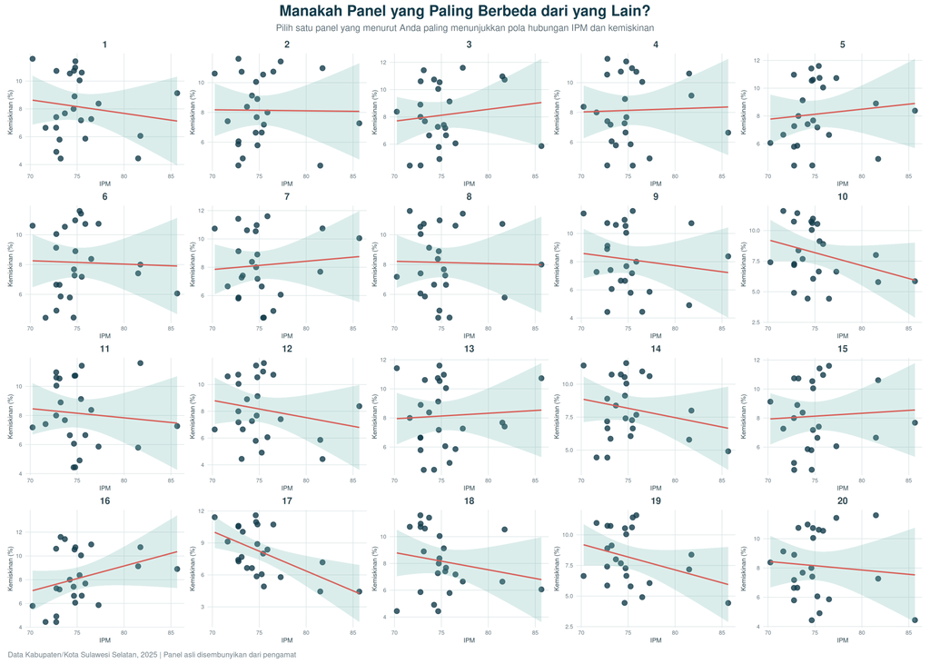

Lineup hubungan IPM dan kemiskinan; panel asli tidak ditandai pada gambar

## 7.1 Hasil pengamatan dan uji binomial

Dari 10 responden, 7 orang memilih Panel 17, yaitu panel asli. Proporsi jawaban benar pada kelompok pengamat ini adalah 7/10 atau 70%.

Uji binomial yang dilakukan menggunakan peluang tebakan acak sebesar $P=1/20=0.05$ menghasilkan *p-value* sebesar $8,198 \times 10^-8$. Di bawah asumsi bahwa setiap responden menebak secara independen dengan peluang benar sebesar $0,05$ , jumlah jawaban benar tersebut jauh lebih tinggi daripada yang diharapkan jika responden hanya menebak secara acak.

Namun, hasil ini perlu dipahami sesuai dengan metode pengujian yang digunakan dan tidak serta-merta mewakili seluruh pendekatan perhitungan visual p-value dalam analisis lineup. Selain itu, hasil ini tidak membuktikan adanya hubungan sebab-akibat antara IPM dan kemiskinan.